# Tutorial for sequential ordinal pattern tests

## Libraries

```julia
using StatsOrdinalPatterns, Random, Statistics, DataFrames, CairoMakie
```

## Sequential testing with ordinal patterns

A classical test judges a complete series at once. A sequential test (control chart) instead monitors an incoming stream: after each new observation the ordinal pattern of the last $m$ values is determined and its indicator vector $\mathbf{e}_t$ (length $m!$) is smoothed exponentially (EWMA),

$$\hat{\mathbf{p}}_t = \lambda\,\mathbf{e}_t + (1 - \lambda)\,\hat{\mathbf{p}}_{t-1},
\qquad \hat{\mathbf{p}}_0 = (1/m!, \ldots, 1/m!),$$

with smoothing parameter $\lambda \in (0, 1]$. The chart statistic is computed from $\hat{\mathbf{p}}_t$ and the chart signals as soon as the statistic leaves the critical limit `cl`. The number of observations until the first signal is the run length (RL).

Designing such a chart means fixing $\lambda$ and then choosing `cl` so that the **in-control average run length** (ARL) matches a target `L0` (typically 370 or 500). Chart performance is then judged by the **out-of-control ARL**: the smaller, the faster dependence is detected. See Weiß and Testik (2023).

## Key functions

- **Critical limit**
  - `cl_op(op_dgp, lam, L0, cl_init; chart_choice, m=3, d=1, reps_bracket, reps_final, bracket_step, seed)`
    - Returns the `cl` for which the in-control ARL equals `L0`.
    - `op_dgp`: in-control process, `ContinuousDGPIC(dist)` or `DiscreteDGPIC(dist, add_noise)`.
    - `cl_init`: rough starting value; the search first brackets the root with `reps_bracket` replications in steps of `bracket_step`, then refines it with `reps_final` replications.
    - `seed`: fix an integer for reproducible results.
- **Chart performance**
  - `arl_op_ic(op_dgp, lam, cl, reps; chart_choice, m=3, d=1)` — in-control ARL, returns `(ARL, standard error)`.
  - `arl_op_oc(op_dgp, lam, cl, reps; chart_choice, m=3, d=1)` — out-of-control ARL for a dependent process: `AR1`, `MA1`, `MA2`, `TEAR1`, `AAR1`, `QAR1` for continuous data, `INAR1`, `DAR1`, `BAR1`, … for counts.
- **Monitoring observed data**
  - `stat_op(data, lam; chart_choice, m=3, d=1)` — returns `(stats, p_rel)`, where `stats` holds the sequentially computed EWMA chart statistics of the series.
  - `monitor_op(data, lam, cl; chart_choice, m=3, d=1)` — applies the alarm rule of the chart to these statistics and returns a `ControlChartResult` with the statistics, the limit and the first alarm. With Makie loaded, `plot` draws it.

## Alarm rules

The same seven statistics as in the classical tests are available; the alarm rule follows the direction of the statistic.

| Statistic | Constructor | Under $H_0$ | Signal when |
| --- | --- | --- | --- |
| Persistence ($\hat{\tau}$) | `Persistence()` | $\hat{\tau} = 0$ | $\lvert\hat{\tau}\rvert > cl$ |
| UpDownBalance ($\hat{\beta}$) | `UpDownBalance()` | $\hat{\beta} = 0$ | $\lvert\hat{\beta}\rvert > cl$ |
| RotationalAsymmetry ($\hat{\gamma}$) | `RotationalAsymmetry()` | $\hat{\gamma} = 0$ | $\lvert\hat{\gamma}\rvert > cl$ |
| UpDownScaling ($\hat{\delta}$) | `UpDownScaling()` | $\hat{\delta} = 0$ | $\lvert\hat{\delta}\rvert > cl$ |
| DistanceToWhiteNoise ($\hat{\Delta}$) | `DistanceToWhiteNoise()` | $\hat{\Delta} = 0$ | $\hat{\Delta} > cl$ |
| Shannon entropy ($\hat{H}$) | [`Shannon(base=exp(1))`](https://juliadynamics.github.io/ComplexityMeasures.jl/stable/information_measures/#ComplexityMeasures.Shannon) | $\hat{H} = \log(m!)$ | $\hat{H} < cl$ |
| Shannon extropy ($\hat{H}_\text{ex}$) | [`ShannonExtropy(base=exp(1))`](https://juliadynamics.github.io/ComplexityMeasures.jl/stable/information_measures/#ComplexityMeasures.ShannonExtropy) | $\hat{H}_\text{ex} = 5\log(6/5)$ | $\hat{H}_\text{ex} < cl$ |

`cl_op` handles the direction internally: for the two entropy charts the ARL *decreases* in `cl`, for all others it increases.

## Setup

```julia
ic = ContinuousDGPIC(Normal(0, 1))   # in-control: i.i.d. standard normal
lam = 0.1                            # EWMA smoothing parameter
L0 = 370.0                           # target in-control ARL
m, d = 3, 1
```

```
(3, 1)
```

## Computing the critical limit

```julia
cl = cl_op(
    ic, lam, L0, 0.20;
    chart_choice=Persistence(), m=m, d=d,
    reps_bracket=1_000, reps_final=5_000, bracket_step=0.02, seed=42,
    verbose=true
)
```

```
============================================================
 STEP 1: Bracket Search
 reps = 1000 | truncation cap = 18500 | step size = 0.02
============================================================
  cl = 0.2 | ARL = 83.176
  cl = 0.22 | ARL = 142.344
  cl = 0.24 | ARL = 245.676
  cl = 0.26 | ARL = 479.155
------------------------------------------------------------
 Bracket found: [0.2, 0.26]
------------------------------------------------------------

============================================================
 STEP 2: Root Finding via ITP
 reps = 5000 | no truncation | tolerance = 0.0001
============================================================
  cl = 0.2 | ARL = 83.753
  cl = 0.26 | ARL = 467.8048
  cl = 0.244 | ARL = 283.64
  cl = 0.251554 | ARL = 359.2096
  cl = 0.252408 | ARL = 367.785
  cl = 0.252587 | ARL = 369.6772
  cl = 0.2536 | ARL = 381.9754
  cl = 0.252614 | ARL = 369.7836
  cl = 0.252632 | ARL = 369.7836
  cl = 0.2528 | ARL = 371.0074
  cl = 0.252661 | ARL = 369.9982
  cl = 0.252662 | ARL = 369.9982
  cl = 0.2527 | ARL = 370.2616
```

```
Results of univariate zero finding:

* Converged to: 0.25266172651450286
* Algorithm: Roots.ITP{Float64, Int64}(0.2, 2, 1)
* iterations: 11
* function evaluations ≈ 13
* stopped as x_n ≈ x_{n-1} using atol=xatol, rtol=xrtol

Trace:
(a₀, b₀) = ( 0.20000000000000001, 0.26000000000000001 )
(a₁, b₁) = ( 0.24400006120007772, 0.26000000000000001 )
(a₂, b₂) = ( 0.25155407738768609, 0.26000000000000001 )
(a₃, b₃) = ( 0.25240756060663316, 0.26000000000000001 )
(a₄, b₄) = ( 0.25258722887481488, 0.26000000000000001 )
(a₅, b₅) = ( 0.25258722887481488, 0.25359999999999999 )
(a₆, b₆) = ( 0.25261401697267649, 0.25359999999999999 )
(a₇, b₇) = ( 0.2526317122440343, 0.25359999999999999 )
(a₈, b₈) = ( 0.2526317122440343, 0.25279999999999997 )
(a₉, b₉) = ( 0.25266147560584368, 0.25279999999999997 )
(a₁₀, b₁₀) = ( 0.25266172651450286, 0.25279999999999997 )
(a₁₁, b₁₁) = ( 0.25266172651450286, 0.25269999999999998 )
```

```
0.25266172651450286
```

`verbose=true` prints `cl` and the associated ARL at every evaluation, so both phases of the search can be followed: the bracketing steps away from `cl_init` until the ARL crosses `L0`, then the ITP algorithm refines the bracket. It is worth checking that the bracketing does not crawl — `cl_init = 0.20` only has to be in the right ballpark, but it should sit *below* the root and `bracket_step` should be of the order of the remaining distance.

Increase `reps_final` for a more precise limit — the accuracy of `cl` is limited by the Monte Carlo error of the ARL estimate, not by the root finder. Pass `verbose=false` (the default) to get the limit alone.

## Verifying the in-control ARL

```julia
arl_op_ic(ic, lam, cl, 10_000; chart_choice=Persistence(), m=m, d=d)
```

```
(365.2791, 3.552213651021184)
```

The returned tuple is `(ARL, standard error)`; the ARL is within a few standard errors of `L0`.

## Out-of-control performance

The same `cl` is used to monitor dependent processes. The stronger the dependence, the faster the chart signals.

```julia
oc_dgps = [
    ("AR(1), α = 0.1", AR1(0.1, Normal(0, 1))),
    ("AR(1), α = 0.25", AR1(0.25, Normal(0, 1))),
    ("AR(1), α = 0.5", AR1(0.5, Normal(0, 1))),
    ("MA(1), α = 0.5", MA1(0.5, Normal(0, 1))),
    ("TEAR(1), α = 0.5", TEAR1(0.5, Normal(0, 1))),
    ("INAR(1), α = 0.5", INAR1(0.5, Poisson(5), true)),
]
oc_res = [
    arl_op_oc(dgp, lam, cl, 10_000; chart_choice=Persistence(), m=m, d=d)
    for (_, dgp) in oc_dgps
]
```

```julia
DataFrame(
    Process=[n for (n, _) in oc_dgps],
    ARL=round.([r[1] for r in oc_res], digits=2),
    se=round.([r[2] for r in oc_res], digits=3),
)
```

6×3 DataFrame

| Row | Process String | ARL Float64 | se Float64 |
| --- | --- | --- | --- |
| 1 | AR(1), α = 0.1 | 268.5 | 2.593 |
| 2 | AR(1), α = 0.25 | 160.56 | 1.501 |
| 3 | AR(1), α = 0.5 | 76.74 | 0.693 |
| 4 | MA(1), α = 0.5 | 259.28 | 2.521 |
| 5 | TEAR(1), α = 0.5 | 73.39 | 0.658 |
| 6 | INAR(1), α = 0.5 | 77.79 | 0.701 |

The count process `INAR1(α, dist, add_noise)` uses `add_noise=true`, which breaks ties by adding uniform noise — otherwise equal values would make the ordinal pattern ambiguous.

## Comparing charts

Each chart needs its own critical limit, because the statistics live on different scales. Once all charts are calibrated to the same `L0`, their out-of-control ARLs are directly comparable.

```julia
chart_list = [
    ("Persistence (τ)", Persistence(), 0.20, 0.02),
    ("UpDownBalance (β)", UpDownBalance(), 0.30, 0.03),
    ("RotationalAsymmetry (γ)", RotationalAsymmetry(), 0.30, 0.03),
    ("DistanceToWhiteNoise (Δ)", DistanceToWhiteNoise(), 0.08, 0.01),
    ("Shannon entropy (H)", Shannon(base=exp(1)), 1.40, 0.02),
]

oc_dgp = AR1(0.25, Normal(0, 1))
cls = [
    cl_op(ic, lam, L0, init; chart_choice=c, m=m, d=d,
        reps_bracket=1_000, reps_final=5_000, bracket_step=step, seed=42)
    for (_, c, init, step) in chart_list
]
ic_arls = [
    arl_op_ic(ic, lam, cls[i], 10_000; chart_choice=chart_list[i][2], m=m, d=d)[1]
    for i in eachindex(chart_list)
]
oc_arls = [
    arl_op_oc(oc_dgp, lam, cls[i], 10_000; chart_choice=chart_list[i][2], m=m, d=d)[1]
    for i in eachindex(chart_list)
]
```

```julia
DataFrame(
    Chart=[t[1] for t in chart_list],
    cl=round.(cls, digits=4),
    ARL_ic=round.(ic_arls, digits=1),
    ARL_oc=round.(oc_arls, digits=1),
)
```

5×4 DataFrame

| Row | Chart String | cl Float64 | ARL_ic Float64 | ARL_oc Float64 |
| --- | --- | --- | --- | --- |
| 1 | Persistence (τ) | 0.2527 | 365.3 | 158.0 |
| 2 | UpDownBalance (β) | 0.3623 | 361.5 | 251.3 |
| 3 | RotationalAsymmetry (γ) | 0.4057 | 367.5 | 413.7 |
| 4 | DistanceToWhiteNoise (Δ) | 0.1111 | 365.9 | 210.1 |
| 5 | Shannon entropy (H) | 1.4614 | 357.2 | 269.1 |

All charts hold the in-control ARL near `L0 = 370`, so the `ARL_oc` column ranks them: the smaller the value, the faster this particular AR(1) dependence is detected. The ranking is specific to the alternative — $\hat{\gamma}$ measures rotational asymmetry, which an AR(1) process does not induce, so its chart stays at roughly the in-control level.

## Monitoring an observed series

`monitor_op(data, lam, cl; ...)` computes the EWMA chart statistics of an observed series (the same ones `stat_op(data, lam; ...)` returns), applies the alarm rule of the chosen chart and records the first signal. Here the series switches from i.i.d. to AR(1) at $t = 150$.

```julia
Random.seed!(4)
t_change = 150
x = randn(400)
for t in (t_change+1):400
    x[t] = 0.5 * x[t-1] + randn()
end

res = monitor_op(x, lam, cl; chart_choice=Persistence(), m=m, d=d)
```

```
ControlChartResult
  Family:           ordinal patterns (OP)
  Chart:            Persistence()
  λ:                0.1
  Control limit:    0.2527
  Alarm rule:       |stat| > cl
  Statistics:       398 (observations 3 to 400)
  First alarm:      observation 178 (statistic 0.2616)
```

The statistic at position $i$ of `res.stats` is computed from the pattern covering the observations $i, \ldots, i + (m-1)d$, so it becomes available at the last of them. This observation index is stored in `res.time`, and `res.alarm` is the position of the first signal in `res.stats`:

```julia
(first_alarm=res.time[res.alarm], delay=res.time[res.alarm] - t_change,
 stat_at_alarm=round(res.stats[res.alarm], digits=4))
```

```
(first_alarm = 178, delay = 28, stat_at_alarm = 0.2616)
```

Here the chart passes the i.i.d. part without a false alarm and signals shortly after the change. A different series may well signal earlier: with `L0 = 370`, a false alarm occurs on average once every 370 in-control observations.

With `CairoMakie` loaded, `plot` shows the statistics against the control limits, shades the rejection region and marks the first alarm. See the plotting tutorial for the options.

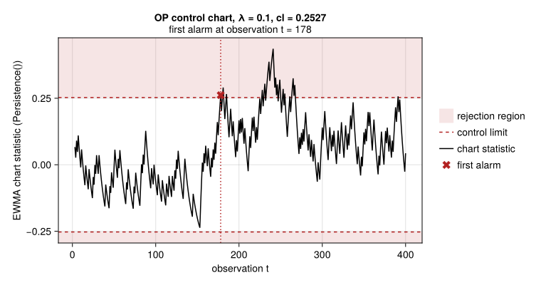

```julia
plot(res)
```

## References

Weiß, Christian H, and Murat Caner Testik. 2023. “Nonparametric Control Charts for Monitoring Serial Dependence Based on Ordinal Patterns.” *Technometrics* 65 (3): 340–50.